# Part II - Effects of User types, Genders, Cities and Bike sharing options on Bike trip durations

## by Lam Tong

## Investigation Overview

In this investigation, I wanted to look at the factors that could be affect on trip durations. The main focus was on: User types, Genders, Cities and Bike sharing options.

## Dataset Overview

The dataset contains data of 183412 rides in February 2019 of the Ford Gobike bike-sharing system, with 12 detailed info, including: Duration (in seconds/minutes), Start/End time, Start/End Stations data names, City, , Users data (Year of birth, gender), bike sharing options. The added 'city' column tells the city of the station the bike was taken for each ride. The 'member_age' column contains customer ages (at 2019). The duration(h:m:s) column with the duration of each ride in Hours:Minutes:Seconds format.

## Distribution of trip durations

Trip durations in the dataset take on a very large range of values, from about only 1 minute at the lowest, to about 1424 minutes (23 hours and 43 minutes) at the highest. The average duration time is 12.1 minutes. Plotted on a logarithmic scale, the distribution of trip durations takes on a unimodal shape.

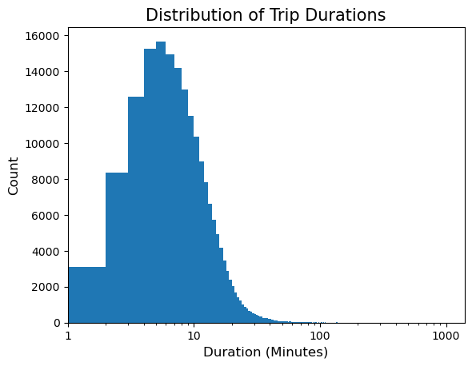

## Number of trips by duration ranges

Most of the trips are less than 15 minutes. While the figure for the trips within 15-30 minutes was 28,564. Trips takes more than 1 hours only hold small percentage of the total figure.

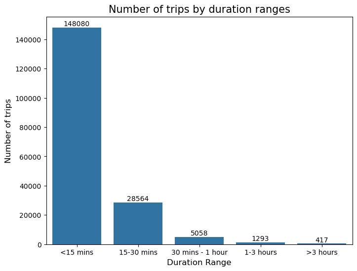

## Number of trips in each city

The number of trips in San Francisco was the highest with 133708 trips in Feb 2019. Trips counted in Oakland was 20434 slightly higher than Berkeley counterpart, acounted for 19449 trips. The number of trips in San Jose and Emeryville were 8270 and 1551, respectively.

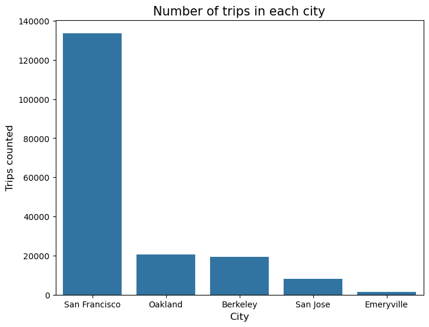

## Number of trips by user types

89.17% of the service are used by Subscribers, as 8 times as much as that of non-subscribers (Customers), with 10.83%

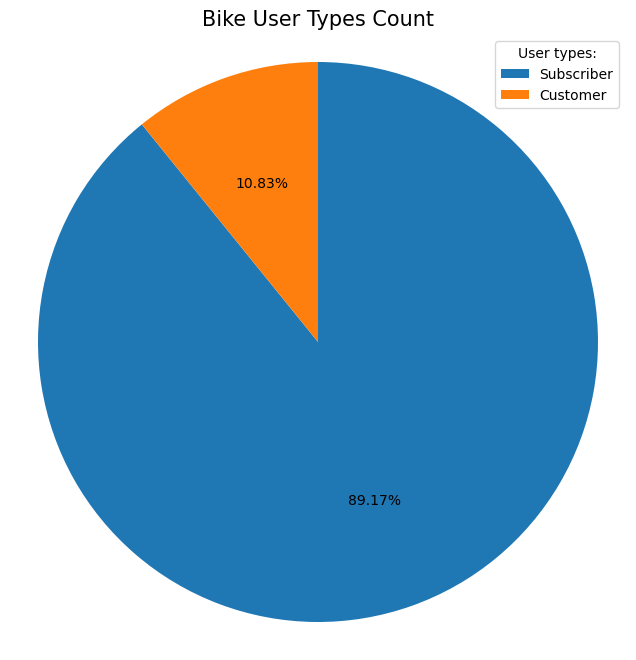

## Relation between user types and trips duration

Users who did't subribe had longer trips than subscribers.

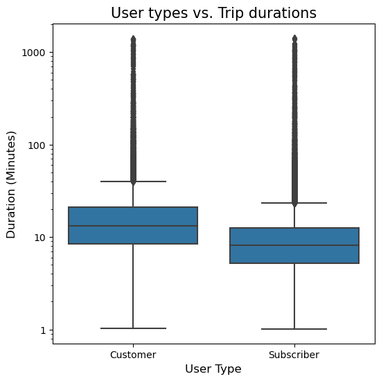

## Relation between genders and trips duration

Males have shorter trips than other genders.

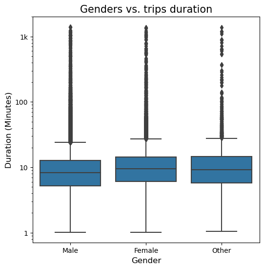

## Relation between bike sharing options and trips duration

Trips with bike sharing option were shorter than those were without this option.

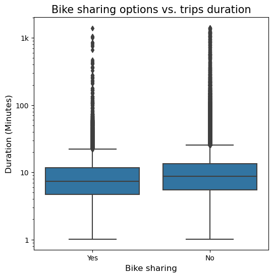

## Average trips duration each day of Feb-2019, by gender

Female average duration was higher than male counterpart. Male and female daily average trip durations seem to had the similar trends.

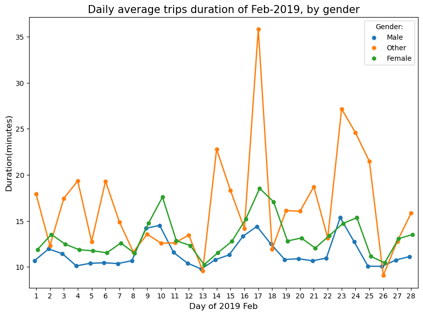

## Daily average trips duration of Feb-2019, by subscription status

Though the average trip durations of Customers were higher than Subscriber's. Subscribers tends to have stable duration usage than non-subscribers

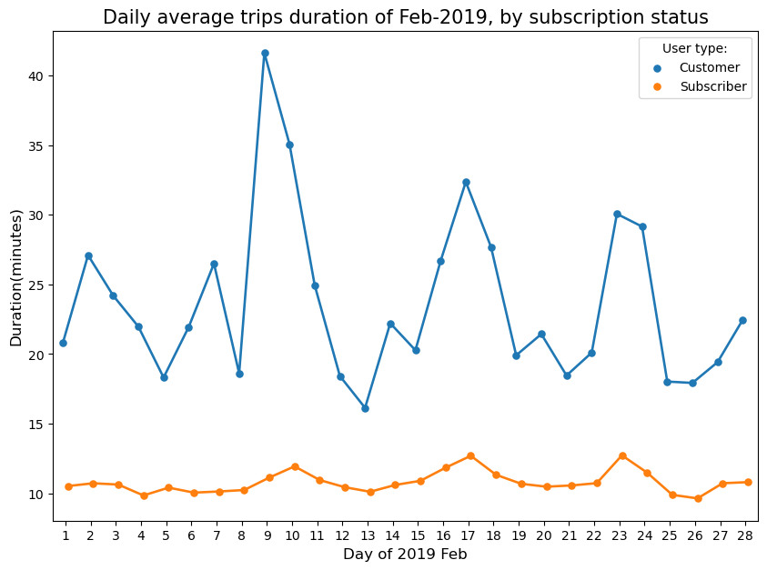